# Data Importing/Exporting and interaction with other programmes

This chapter is for code examples of data importing/exporting and interactions with other programmes and databases.

## Libraries

```r
library(tidyverse)
library(DBI)
library(dbplyr)
library(haven)
library(bigrquery)
library(fs)
library(haven)
```

```r
library(tidyverse)
library(fs) #cross-platform file systems operations (based on libuv C library)
library(knitr) #general purpose tool for dynamic report generation in R
library(kableExtra) #presentation of complex tables with customizable styles
library(DT) #presentation of tables (wrapper of JavaScript library DataTables)
library(DBI) #database connection
library(dbplyr) #database connection
library(haven) #for importing/exporting SPSS, Stata, and SAS files
library(bigrquery) #connecting to GCP BigQuery
library(openxlsx) #formatting xslx outputs
library(xltabr) #MoJ RAP enabler built on openxlsx
```

# Star functions

- `readxl::read_excel`
- `readxl::excel_sheets`
- `purrr::map_dfr`
- `purrr::map_dfc`
- `purrr::map2_dfc`
- `fs::dir_ls`

## Navigating folders

A couple of pointers to navigate from your working directory, which, if you’re using R projects (it is highly recommended that you do) will be wherever the `.Rproj` file is located

### Down

To navigate down folders use `/`. The path given below saves the file **my_df.csv** in the **data** folder, which itself is inside the **monthly_work** folder

```r
readr::write_csv(
  x = my_dataframe
  , path = "monthly_work/data/my_df.csv"
)
```

### Up

To go up a folder use `../`. In particular you may need to do this when running Rmarkdown files. Rmarkdown files use their location as the working directory. If you have created an **R** folder, say, to stash all your scripts in, and a **data** folder to stash your data files in, then you will need to go up, before going down…

The path below goes up one folder, then into the **data** folder, where the **lookup_table.csv** is located.

```r
lookup_table <- readr::read_csv(
  file = "../data/lookup_table.csv"
)
```

## Working with files in R

This section focusses on reading in various filetypes for working on in R memory.

### .rds

.rds is R’s native file format, any object you create in R can be saved as a .rds file. The functions `readRDS` and `saveRDS` are base R functions.

```r
#not run
saveRDS(
  object = my_model #specify the R object you want to save
  , file = "2019_0418_my_model.rds" #give it a name, don't forget the file extension
)
```

### .csv

We use the functions `read_csv` and `write_csv` from the `readr` package (which is part of the `tidyverse`). These are a little bit *cleverer* than their base counterparts, however, this cleverness can catch you out.

The file **messy_pokemon_data.csv** contains pokemon go captures data which has been deliberately messed up a bit. `read_csv` imputes the column specification from the first 1000 rows, which is fine if your first 1000 rows are representative of the data type. If not then subsequent data that can’t be coerced into the imputed data type will be replaced with NA.

```r
pokemon <- readr::read_csv(
  file = "data/messy_pokemon_data.csv"
)
```

Let’s have a quick look at some data from these columns

```r
pokemon %>%
  dplyr::select(species, combat_power, date_first_capture, time_first_capture) %>%
  dplyr::arrange(desc(combat_power)) %>%
  head()
```

```
## # A tibble: 6 x 4
##   species    combat_power date_first_capture time_first_capture
##   <chr>      <chr>        <chr>              <time>
## 1 electabuzz P962         29/04/2001         08:20
## 2 pidgey     P95          27/11/1969         21:59
## 3 drowzee    P613         18/07/1968         10:36
## 4 bulbasaur  P577         17 June 1997       09:17
## 5 drowzee    P542         04/07/1928         21:54
## 6 drowzee    P518         06/09/1950         17:01
```

The pokemon dataset has less than 1000 rows so `read_csv` has ‘seen’ the letters mixed in with some of the numbers in the **combat_power** column. It has guessed at character type because everything it has read in the column can be coerced to character type.

What if there are more than 1000 rows? For example, say you have a numeric column, but there are some letters prefixed to the numbers in some of the post-row-1000 rows. These values are still meaningful to you, and with some data wrangling you can extract the actual numbers. Unfortunately `read_csv` has guessed at type double based on the first 1000 rows and since character type cannot be coerced into double, these values will be replaced with `NA`. If you have messy data like this the best thing to do is to force `read_csv` to read in as character type to preserve all values as they appear, you can then sort out the mess yourself.

You can specify the column data type using the `col_types` argument. Below I have used a compact string of abbreviations to specify the column types, see the help at `?read_csv` or the `readr` vignette for the full list. You can see I got many parsing failures, which I can access with `problems()`, which is a data frame of the values that `read_csv` was unable to coerce into the type I specified, and so has replaced with NA.

```r
pokemon <- readr::read_csv(
  file = "data/messy_pokemon_data.csv"
  , col_types = "cdddcdcccDt"
)
# c = character, d = double, D = Date, t = time
tibble::glimpse(pokemon)
```

```
## Observations: 696
## Variables: 11
## $ species            <chr> "abra", "abra", "bellsprout", "bellsprout", "…
## $ combat_power       <dbl> 101, 81, 156, 262, 389, 433, 628, 161, 135, 4…
## $ hit_points         <dbl> 20, 16, 32, 44, 50, 59, 68, 33, 29, 51, 26, 6…
## $ weight_kg          <dbl> 17.18, 25.94, 5.85, 5.42, 3.40, 6.67, 3.84, 1…
## $ weight_bin         <chr> "normal", "extra_large", "extra_large", "extr…
## $ height_m           <dbl> 0.85, 1.00, 0.80, 0.82, 0.66, 0.84, 0.78, 0.3…
## $ height_bin         <chr> "normal", "normal", "normal", "normal", "norm…
## $ fast_attack        <chr> "zen_headbutt", "zen_headbutt", "acid", "acid…
## $ charge_attack      <chr> "shadow_ball", "shadow_ball", "sludge_bomb", …
## $ date_first_capture <date> NA, NA, NA, NA, NA, NA, NA, NA, NA, NA, NA, …
## $ time_first_capture <time> 20:59:33, 10:18:40, 08:06:55, 11:18:28, 21:1…
```

Let’s take a look at the problems.

```r
problems(pokemon) %>%
  head()
```

```
## # A tibble: 6 x 5
##     row col              expected     actual        file
##   <int> <chr>            <chr>        <chr>         <chr>
## 1     1 date_first_capt… "date like " 31 May 1977   'data/messy_pokemon_da…
## 2     2 date_first_capt… "date like " 24 February … 'data/messy_pokemon_da…
## 3     3 date_first_capt… "date like " 21 June 1924  'data/messy_pokemon_da…
## 4     4 date_first_capt… "date like " 01 August 19… 'data/messy_pokemon_da…
## 5     5 date_first_capt… "date like " 06 August 19… 'data/messy_pokemon_da…
## 6     6 date_first_capt… "date like " 17 January 1… 'data/messy_pokemon_da…
```

And since I know that there are problems with **combat_power** let’s take a look there.

```r
problems(pokemon) %>%
  dplyr::filter(col == "combat_power") %>%
  head()
```

```
## # A tibble: 6 x 5
##     row col          expected actual file
##   <int> <chr>        <chr>    <chr>  <chr>
## 1    12 combat_power a double P577   'data/messy_pokemon_data.csv'
## 2    96 combat_power a double P458   'data/messy_pokemon_data.csv'
## 3    97 combat_power a double P455   'data/messy_pokemon_data.csv'
## 4    98 combat_power a double P518   'data/messy_pokemon_data.csv'
## 5    99 combat_power a double P348   'data/messy_pokemon_data.csv'
## 6   100 combat_power a double P542   'data/messy_pokemon_data.csv'
```

The `problems()` feature in `read_csv` is super useful, it helps you isolate the problem data so you can fix it.

Other arguments within `read_csv` that I will just mention, with their default settings are

- `col_names = TRUE`: the first row on the input is used as the column names.
- `na = c("", "NA")`: the default values to interpret as `NA`.
- `trim_ws = TRUE`: by default trims leading/trailing white space.
- `skip = 0`: number of lines to skip before reading data.
- `guess_max = min(1000, n_max)`: maximum number of records to use for guessing column type. NB the bigger this is the longer it will take to read in the data.

### .xlsx and .xls

Excel workbooks come in many shapes and sizes. You may have one or many worksheets in one or many workbooks, there may only be certain cells that you are interested in. Below are a few examples of how to cope with these variations using functions from `readxl` and `purrr` to iterate over either worksheets and/or workbooks, the aim being to end up with all the data in a single tidy dataframe.

#### Single worksheet - single workbook

The simplest combination, you are interested in one rectangular dataset in a particular worksheet in one workbook. Leaving the defaults works fine on this dataset. Note that `readxl::read_excel` detects if the file is `.xlsx` or `.xls` and behaves accordingly.

```r
readxl::read_excel(path = "data/port0499.xlsx") %>%
  head()
```

```
## # A tibble: 6 x 9
##    year polu_majorport polu_region direction cargo_group cargo_category
##   <dbl> <chr>          <chr>       <chr>     <chr>                <dbl>
## 1  2000 Aberdeen       Africa (ex… Inwards   Other Gene…             92
## 2  2000 Aberdeen       Africa (ex… Outwards  Other Gene…             92
## 3  2000 Aberdeen       Africa (ex… Outwards  Other Gene…             99
## 4  2000 Aberdeen       America     Inwards   Other Gene…             91
## 5  2000 Aberdeen       America     Inwards   Other Gene…             92
## 6  2000 Aberdeen       America     Outwards  Other Gene…             99
## # … with 3 more variables: cargo_description <chr>, tonnage <dbl>,
## #   units <dbl>
```

Let’s set a few of the other arguments, run `?read_excel` in the console to see the full list.

```r
readxl::read_excel(
  path = "data/port0499.xlsx"
  , sheet = 1 #number or name of sheet, default is first sheet
  , col_names = TRUE #default
  , col_types = "text" #a single type will recycle to all columns, specify each using character vector of the same length eg c("numeric", "text", ...)
) %>%
  head()
```

```
## # A tibble: 6 x 9
##   year  polu_majorport polu_region direction cargo_group cargo_category
##   <chr> <chr>          <chr>       <chr>     <chr>       <chr>
## 1 2000  Aberdeen       Africa (ex… Inwards   Other Gene… 92
## 2 2000  Aberdeen       Africa (ex… Outwards  Other Gene… 92
## 3 2000  Aberdeen       Africa (ex… Outwards  Other Gene… 99
## 4 2000  Aberdeen       America     Inwards   Other Gene… 91
## 5 2000  Aberdeen       America     Inwards   Other Gene… 92
## 6 2000  Aberdeen       America     Outwards  Other Gene… 99
## # … with 3 more variables: cargo_description <chr>, tonnage <chr>,
## #   units <chr>
```

#### Single worksheet - many workbooks

For example, you collect pokemon go capture data from many different players, the data all has the same structure and you want to read it in and row bind into a single dataframe in R.

[figure not shown]

The code below collects the names of the 3 excel workbooks using `fs::dir_ls`, and, as these are not the only files in that folder, I’ve specified them using regular expressions (regex). Then we use `purrr::map_dfr` to iterate and rowbind over this list of files, applying the function we supply, that is `readxl::read_excel`. Since we are only reading a single worksheet per workbook we don’t need to supply any arguments to `readxl:read_excel`, the defaults will work fine, each workbook path is piped in, in turn. The `.id` argument in `purrr:map_dfr` adds the file path into a new column, which we have named “player” in this instance. The “dfr” in `map_dfr` refers to the output “data-frame-rowbound”.

```r
pokemon <- fs::dir_ls(path = "data", regex = "pokemon_player_.\\.xlsx$")  %>%
  purrr::map_dfr(.f = readxl::read_excel, .id = "player")

tibble::glimpse(pokemon)
```

```
## Observations: 15
## Variables: 10
## $ player        <chr> "data/pokemon_player_a.xlsx", "data/pokemon_player…
## $ species       <chr> "krabby", "geodude", "venonat", "parasect", "eevee…
## $ combat_power  <dbl> 51, 85, 129, 171, 172, 10, 234, 20, 173, 157, 249,…
## $ hit_points    <dbl> 15, 23, 38, 32, 37, 11, 33, 20, 26, 49, 50, 10, 13…
## $ weight_kg     <dbl> 5.82, 20.88, 20.40, 19.20, 4.18, 6.21, 73.81, 5.28…
## $ weight_bin    <chr> "normal", "normal", "extra_small", "extra_small", …
## $ height_m      <dbl> 0.36, 0.37, 0.92, 0.87, 0.25, 0.36, 1.52, 0.30, 0.…
## $ height_bin    <chr> "normal", "normal", "normal", "normal", "normal", …
## $ fast_attack   <chr> "mud_shot", "rock_throw", "confusion", "bug_bite",…
## $ charge_attack <chr> "vice_grip", "rock_tomb", "poison_fang", "x-scisso…
```

Using `DT::datatable` for ease of viewing we can see that all 5 rows of data from each of the 3 workbooks has been read in, rowbound, and an id column has been added showing the workbook path.

```r
DT::datatable(data = pokemon)
```

|  | player | species | combat_power | hit_points | weight_kg | weight_bin | height_m | height_bin | fast_attack | charge_attack |
| --- | --- | --- | --- | --- | --- | --- | --- | --- | --- | --- |
| 1 | data/pokemon_player_a.xlsx | krabby | 51 | 15 | 5.82 | normal | 0.36 | normal | mud_shot | vice_grip |
| 2 | data/pokemon_player_a.xlsx | geodude | 85 | 23 | 20.88 | normal | 0.37 | normal | rock_throw | rock_tomb |
| 3 | data/pokemon_player_a.xlsx | venonat | 129 | 38 | 20.4 | extra_small | 0.92 | normal | confusion | poison_fang |
| 4 | data/pokemon_player_a.xlsx | parasect | 171 | 32 | 19.2 | extra_small | 0.87 | normal | bug_bite | x-scissor |
| 5 | data/pokemon_player_a.xlsx | eevee | 172 | 37 | 4.18 | extra_small | 0.25 | normal | tackle | body_slam |
| 6 | data/pokemon_player_b.xlsx | nidoran_female | 10 | 11 | 6.21 | normal | 0.36 | normal | bite | poison_fang |
| 7 | data/pokemon_player_b.xlsx | kingler | 234 | 33 | 73.81 | normal | 1.52 | normal | metal_claw | vice_grip |
| 8 | data/pokemon_player_b.xlsx | magnemite | 20 | 20 | 5.28 | normal | 0.3 | normal | thunder_shock | magnet_bomb |
| 9 | data/pokemon_player_b.xlsx | koffing | 173 | 26 | 0.53 | extra_small | 0.49 | normal | acid | sludge |
| 10 | data/pokemon_player_b.xlsx | rhyhorn | 157 | 49 | 90.57 | normal | 0.94 | normal | rock_smash | horn_attack |

[output cut: 5 more lines]

Note that the `regex` argument in `fs::dir_ls` is applied to the full file path so if I had tried to specify that the file name starts with “pokemon” by front anchoring it using “^pokemon” this would return no results, since the full name is actually “data/pokemon…”. Helpful regex links below.

[regex cheatsheet](https://www.rstudio.com/wp-content/uploads/2016/09/RegExCheatsheet.pdf)

[stringr cheatsheet including regex](http://edrub.in/CheatSheets/cheatSheetStringr.pdf)

#### Many worksheets - single workbook

You have a single workbook, but it contains many worksheets of interest, each containing rectangular data with the same structure. For example, you have a workbook containing pokemon go captures data, where each different data collection point has its own sheet. The data structure, column names and data types are consistent. You want to read in and combine these data into a single dataframe.

The code below sets the location of the workbook and puts this in the object `path`. It then collects the names of all the sheets in that workbook using `readxl::excel_sheets`. Next `purrr::set_names` sets these names in a vector so that they can be used in the next step. This vector of names is implictly assigned to the `.x` argument in `purrr::map_dfr` as it is the first thing passed to it. This means we can refer to it as `.x` in the function we are iterating, in this case `readxl::read_excel`. Finally, an id column is included, made up of the sheet names and named “sheet”. The output is a single dataframe with all the sheets row bound together.

```r
path <- "data/multi_tab_messy_pokemon_data.xlsx"
pokemon_collections <- readxl::excel_sheets(path = path) %>%
  purrr::set_names() %>%
   purrr::map_dfr(
     ~ readxl::read_excel(path = path, sheet = .x)
     , .id = "sheet"
   )
DT::datatable(data = pokemon_collections)
```

|  | sheet | species | combat_power | hit_points | weight_kg | weight_bin | height_m | height_bin | fast_attack | charge_attack |
| --- | --- | --- | --- | --- | --- | --- | --- | --- | --- | --- |
| 1 | collection_point_1 | jigglypuff | 56 | 51 | 5.55 | normal | 0.49 | normal | feint_attack | play_rough |
| 2 | collection_point_1 | caterpie | 212 | 53 | 1.84 | extra_small | 0.28 | normal | bug_bite | struggle |
| 3 | collection_point_1 | koffing | 440 | 43 | 0.93 | normal | 0.53 | normal | acid | sludge_bomb |
| 4 | collection_point_1 | drowzee | 283 | 53 | 37.03 | normal | 1.09 | normal | pound | psychic |
| 5 | collection_point_1 | growlithe | 624 | 66 | 24.43 | extra_large | 0.8 | normal | bite | body_slam |
| 6 | collection_point_1 | pidgey | 199 | 40 | 1.56 | normal | 0.3 | normal | quick_attack | aerial_ace |
| 7 | collection_point_2 | weedle | 158 | 43 | 2.94 | normal | 0.27 | normal | poison_sting | struggle |
| 8 | collection_point_2 | venomoth | 77 | 13 | 10.72 | normal | 1.48 | normal | bug_bite | poison_fang |
| 9 | collection_point_2 | slowpoke | 206 | 62 | 38.09 | normal | 1.13 | normal | confusion | psyshock |
| 10 | collection_point_2 | rattata | 40 | 16 | 4.71 | extra_large | 0.34 | normal | tackle | body_slam |

[output cut: 4 more lines]

#### Many worksheets - many workbooks

Now we can use the above two solutions to combine data from many worksheets spread across many workbooks. As before, the data is rectangular and has the same structure. For example, you receive a workbook every month, containing pokemon go captures data, and each data collection point has its own sheet.

[figure not shown]

We create a function to import and combine the sheets from a single workbook, and then iterate this function over all the workbooks using `purrr::map_df`.

```r
#function to combine sheets from a single workbook
read_and_combine_sheets <- function(path){
  readxl::excel_sheets(path = path) %>%
  purrr::set_names() %>%
   purrr::map_df(
     ~ readxl::read_excel(path = path, sheet = .x)
     , .id = "sheet"
   )
}
#code to iterate over many workbooks
pokemon_monthly_collections <- fs::dir_ls(
  path = "data", regex = "pokemon_2019\\d{2}\\.xlsx$")  %>%
  purrr::map_df(
    read_and_combine_sheets
    , .id = "month"
    )
DT::datatable(data = pokemon_monthly_collections)
```

|  | month | sheet | species | combat_power | hit_points | weight_kg | weight_bin | height_m | height_bin | fast_attack | charge_attack |
| --- | --- | --- | --- | --- | --- | --- | --- | --- | --- | --- | --- |
| 1 | data/pokemon_201901.xlsx | collection_point_1 | horsea | 119 | 21 | 4.62 | extra_small | 0.29 | extra_small | bubble | bubble_beam |
| 2 | data/pokemon_201901.xlsx | collection_point_1 | geodude | 225 | 38 | 18.16 | normal | 0.4 | normal | tackle | rock_slide |
| 3 | data/pokemon_201901.xlsx | collection_point_1 | drowzee | 213 | 46 | 25.17 | normal | 0.85 | normal | pound | psychic |
| 4 | data/pokemon_201901.xlsx | collection_point_1 | eevee | 234 | 46 | 5.33 | normal | 0.3 | normal | tackle | body_slam |
| 5 | data/pokemon_201901.xlsx | collection_point_1 | goldeen | 59 | 19 | 10.83 | extra_small | 0.54 | normal | mud_shot | horn_attack |
| 6 | data/pokemon_201901.xlsx | collection_point_2 | eevee | 44 | 19 | 9.82 | extra_large | 0.34 | normal | tackle | dig |
| 7 | data/pokemon_201901.xlsx | collection_point_2 | ekans | 95 | 24 | 5.2 | normal | 1.93 | normal | acid | gunk_shot |
| 8 | data/pokemon_201901.xlsx | collection_point_2 | eevee | 195 | 40 | 6.02 | normal | 0.28 | normal | tackle | swift |
| 9 | data/pokemon_201901.xlsx | collection_point_2 | drowzee | 44 | 21 | 41.36 | extra_large | 1.09 | normal | confusion | psyshock |
| 10 | data/pokemon_201901.xlsx | collection_point_2 | krabby | 91 | 17 | 5.4 | normal | 0.38 | normal | bubble | vice_grip |

[output cut: 35 more lines]

#### Non-rectangular data - single worksheet - single workbook

You have received some kind of data entry form that has been done in excel in a more human readable, rather than machine readable, format. Some of the cells contain instructions and admin data so you only want the data held in specific cells. This is non-rectangular data, that is, the data of interest is dotted all over the place. In this example we have pet forms, and the data of interest is in cells **B2**, **D5** and **E8** only.

Here’s an image of what the data looks like.

[figure not shown]

Let’s see what we get if we naively try to read it in.

```r
readxl::read_excel(
  path = "data/pet_form_1.xlsx"
) %>%
  knitr::kable() %>%
  kableExtra::kable_styling(full_width = F, position = "left")
```

| Name: | Tiddles | ..3 | ..4 | ..5 |
| --- | --- | --- | --- | --- |
| NA | NA | NA | NA | NA |
| NA | NA | NA | NA | NA |
| NA | NA | Age: | 2 | NA |
| NA | NA | NA | NA | NA |
| NA | NA | NA | NA | NA |
| NA | NA | NA | Species: | cat |

It’s not what we wanted, let’s try again, now using the `range` argument

```r
readxl::read_excel(
  path = "data/pet_form_1.xlsx"
  , col_names = FALSE
  , range = "A2:B2"
) %>%
 knitr::kable() %>%
 kableExtra::kable_styling(full_width = F, position = "left")
```

| ..1 | ..2 |
| --- | --- |
| Name: | Tiddles |

The `range` argument helps, we have picked up one bit of the data, and its name. The `range` argument uses the `cellranger` package which allows you to refer to ranges in Excel files in Excel style. However, we have 3 disconnected data points, we need to iterate, so it’s `purrr` to the rescue once more.

The code below demonstrates explicitly that the `.x` argument in `purrr::map_dfr` takes the vector of things that will be iterated over in the supplied function. In this case we are giving the `range` argument of `readxl::read_excel` three individual cells to iterate over. These will then be rowbound so we end up with a single dataframe comprising a single column, named “cells”, containing 3 rows.

```r
pet_details <- purrr::map_dfr(
    .x = c("B2", "D5", "E8")
    , ~ readxl::read_excel(
      path = "data/pet_form_1.xlsx"
      , range = .x
      , col_names = "cells" #assign name
      , col_types = "text" #have to use text to preserve all data in single column
    )
  )

pet_details
```

```
## # A tibble: 3 x 1
##   cells
##   <chr>
## 1 Tiddles
## 2 2
## 3 cat
```

```r
pet_details %>%
  knitr::kable() %>%
  kableExtra::kable_styling(full_width = F, position = "left")
```

| cells |
| --- |
| Tiddles |
| 2 |
| cat |

This is an improvement, we have a dataframe named `pet_details` comprising a single “cells” column, which contains all the relevant data from this worksheet.

We could now try to reshape it, however, a better idea is to use `map_dfc` since we actually want to column bind these data rather than rowbind them. The read out from `tibble::glimpse` shows that the different variable types have been picked up, which is also helpful. The default naming of the columns gives a clue as to how the function works.

```r
pet_details <- purrr::map_dfc(
  .x = c("B2", "D5", "E8") #vector of specific cells containing the data
  , ~ readxl::read_excel(
    path = "data/pet_form_1.xlsx"
    , range = .x
    , col_names = FALSE
  )
)
tibble::glimpse(pet_details)
```

```
## Observations: 1
## Variables: 3
## $ `..1`  <chr> "Tiddles"
## $ `..11` <dbl> 2
## $ `..12` <chr> "cat"
```

| ..1 | ..11 | ..12 |
| --- | --- | --- |
| Tiddles | 2 | cat |

This is pretty close to what we want, the only sticking point is that we still don’t have the correct column names. We could deal with this using `dplyr::rename`, but an even better idea is to use `purrr::map2_dfc`. The `map2` variant allows you to iterate over two arguments simultaneously (into the same function).

```r
pet_details_2 <- purrr::map2_dfc(
  .x = c("B2", "D5", "E8") #vector of specific data cells
  , .y = c("Name", "Age", "Species") #vector of column names
  , ~ readxl::read_excel(
    path = "data/pet_form_1.xlsx"
    , range = .x
    , col_names = .y
  )
)

tibble::glimpse(pet_details_2)
```

```
## Observations: 1
## Variables: 3
## $ Name    <chr> "Tiddles"
## $ Age     <dbl> 2
## $ Species <chr> "cat"
```

| Name | Age | Species |
| --- | --- | --- |
| Tiddles | 2 | cat |

#### Non-rectangular data - single worksheet - many workbooks

Having solved for one workbook and worksheet, we can functionalise and iterate to gather the data from every wookbook, two of which are shown below.

[figure not shown]

The function `cells_to_rows` below iterates over `read_excel` reading each of the three cells from the worksheet, applying the corresponding column name as it goes. It takes three character or character vector inputs, `path`, `cells`, and `col_names`.

```r
cells_to_rows <- function(path, cells, col_names){
  purrr::map2_dfc(
    .x = cells
    , .y = col_names
    , ~ readxl::read_excel(
      path = path
      , range = .x
      , col_names = .y
    )
  )
}
```

Let’s test it on the first pet form data, first setting the paramaters to use in the function.

```r
path <- "data/pet_form_1.xlsx"
cells <- c("B2", "D5", "E8")
col_names <- c("Name", "Age", "Species")

pet_form_1 <- cells_to_rows(
  path = path, cells = cells, col_names = col_names
  )

pet_form_1
```

```
## # A tibble: 1 x 3
##   Name      Age Species
##   <chr>   <dbl> <chr>
## 1 Tiddles     2 cat
```

| Name | Age | Species |
| --- | --- | --- |
| Tiddles | 2 | cat |

It works! So now we can iterate this over all the pet form workbooks, specifying the paths using regex as before. Note below we use `.x` in the `path` argument in the `cells_to_rows` function to refer to the vector of paths piped to `purrr::map_dfr` from `fs::dir_ls`.

```r
cells <- c("B2", "D5", "E8")
col_names <- c("Name", "Age", "Species")

all_pet_forms <- fs::dir_ls(
  path = "data", regex = "pet_form_\\d\\.xlsx$")  %>%
  purrr::map_dfr(
    ~ cells_to_rows(path = .x, cells = cells, col_names = col_names)
    , .id = "path"
    )

all_pet_forms
```

```
## # A tibble: 4 x 4
##   path                 Name        Age Species
##   <chr>                <chr>     <dbl> <chr>
## 1 data/pet_form_1.xlsx Tiddles     2   cat
## 2 data/pet_form_2.xlsx Woof        1   dog
## 3 data/pet_form_3.xlsx Hammy       0.5 hamster
## 4 data/pet_form_4.xlsx Toothless   3   dragon
```

| path | Name | Age | Species |
| --- | --- | --- | --- |
| data/pet_form_1.xlsx | Tiddles | 2.0 | cat |
| data/pet_form_2.xlsx | Woof | 1.0 | dog |
| data/pet_form_3.xlsx | Hammy | 0.5 | hamster |
| data/pet_form_4.xlsx | Toothless | 3.0 | dragon |

#### Non-rectangular data - many worksheets - single workbook

Now we have more than one worksheet in a single workbook, and the data looks like this, the workbook is from a “pet house” and each worksheet is pet details.

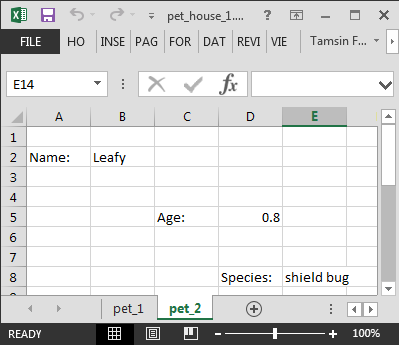

To incorporate the worksheets element we rejig the `cells_to_rows` function from above and give it a “sheet” argument, so it can be passed a specific sheet.

```r
sheet_cells_to_rows <- function(path, sheet, cells, col_names){
  purrr::map2_dfc(
    .x = cells
    , .y = col_names
    , ~ readxl::read_excel(
      path = path
      , sheet = sheet
      , range = .x
      , col_names = .y
    )
  )
}
```

We now have the function `sheet_cells_to_rows` that can accept a list of worksheet names. As before we use `readxl::excel_sheets` to collect the worksheet names, first setting the other parameters

```r
path <- "data/pet_house_1.xlsx"
cells <- c("B2", "D5", "E8")
col_names <- c("Name", "Age", "Species")

pet_house_1 <- readxl::excel_sheets(path = path) %>%
  purrr::set_names() %>%
  purrr::map_dfr(
    ~ sheet_cells_to_rows(path = path
                          , sheet = .x
                          , cells = cells
                          , col_names = col_names)
    , .id = "sheet"
  )

pet_house_1
```

```
## # A tibble: 2 x 4
##   sheet Name      Age Species
##   <chr> <chr>   <dbl> <chr>
## 1 pet_1 Tiddles   2   cat
## 2 pet_2 Leafy     0.8 shield bug
```

| sheet | Name | Age | Species |
| --- | --- | --- | --- |
| pet_1 | Tiddles | 2.0 | cat |
| pet_2 | Leafy | 0.8 | shield bug |

#### Non-rectangular data - many worksheets - many workbooks

Finally we have many workbooks each containing many worksheets, each containing many cells, as before we want to read them in and combine.

[figure not shown]

We could functionalise the code above that reads and combines the cells in many worksheets from a single workbook, but an alternative approach is used below. We create an anonymous function an use that on the fly. This is useful if the function is a one off, and not too complicated. The anonymous function below still depends on the `sheet_cells_to_rows` we created earlier though.

```r
cells <- c("B2", "D5", "E8")
col_names <- c("Name", "Age", "Species")

pet_house_all <- fs::dir_ls(
  path = "data", regex = "pet_house_\\d\\.xlsx$")  %>%
  purrr::map_dfr(
    function(path){
      readxl::excel_sheets(path = path) %>%
        purrr::set_names() %>%
        purrr::map_dfr(
          ~ sheet_cells_to_rows(path = path
                                , sheet = .x
                                , cells = cells
                                , col_names = col_names)
          , .id = "sheet"
        )
    }
    , .id = "path"
  )
```

| path | sheet | Name | Age | Species |
| --- | --- | --- | --- | --- |
| data/pet_house_1.xlsx | pet_1 | Tiddles | 2.0 | cat |
| data/pet_house_1.xlsx | pet_2 | Leafy | 0.8 | shield bug |
| data/pet_house_2.xlsx | pet_1 | Tuuli | 8.0 | tiger |
| data/pet_house_2.xlsx | pet_2 | Sophie | 4.0 | cheetah |
| data/pet_house_2.xlsx | pet_3 | Pearl | 3.0 | Chilean rose tarantula |

### Exporting to .xlsx

We recommend `openxlsx` and `xltabr` for writing and formatting tables to MS Excel. The latter is a wrapper built on `openxlsx` developed by MoJ and is specifically aimed at making it easier to produce publication ready tables. `xltabr` has one known drawback in that it applies the foramtting cell by cell, so if your tables are massive (~100,000 rows) it will take too long, in this instance you should resort to `openxlsx`.

https://cran.r-project.org/web/packages/openxlsx/openxlsx.pdf

https://cran.r-project.org/web/packages/xltabr/xltabr.pdf

Here I am going to go over a few basics of using `xltabr` to produce publication ready output. I’m using an extract of some already published Search and Rescue Helicopter data that was itself produced using `xltabr`, see the full series here.

https://www.gov.uk/government/statistical-data-sets/search-and-rescue-helicopter-sarh01

#### Formatting prep

I’m assuming that the data has already been cleaned, tidied and the unformatted table created in R, most likely using `reshape2::dcast` (see chapter 4) as `xltabr` has bee designed to work well with `reshape2`.

Read in table to be formatted

```r
demo_sarh <- readr::read_csv(
  file = "data/sarh_example.csv"
)
```

The formatting uses a style sheet for reference. This must be created in a .xlsx workbook, and the specific formatting applied to each cell. The cell text will be the name used to reference that style in the code. In the example below anything with style *header* applied to it will be bold, left-justified, and use the same font style, colour and size as in cell A1. It will also apply the row height, but this can be overwritten. You can also apply cell borders, as in styles *top_header_1*, *top_header_2* and *body_bold_method_change*.

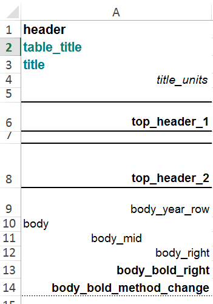

```r
#Variables required to be manually updated  ------------------------------

#table_name_date variables - update these variables as required
latest_month <- "March 2018"
latest_year_end <- "Year ending 31 March 2018"

#footer_text_admin footnote dates and information used - update these variables as required
last_updated <- "December 2017"
next_update <- "June 2018"
contact_telephone <- "some telephone number"
contact_email <- "some email address"

#hyperlink addresses used
hyperlink_sarh <- "https://www.gov.uk/government/collections/search-and-rescue-helicopter-statistics"
names(hyperlink_sarh) <- "DEMO: Search and Rescue Helicopter Statistics"
class(hyperlink_sarh) <- "hyperlink"
#=========================================================================

# Titles ------------------------------------------------------------------
#standard dates used in table_name
table_name_date_01 <- paste0(": April 2017 to ", latest_month)

#function to minimise reptition in input for table titles
set_text_title <- function (table_number, table_name_subheader, table_name_date){
  title_text <- c("DEMO: Department for Transport Statistics"
                  ,"DEMO: Search and Rescue Helicopter Statistics"
                  , table_number
                  , paste0("DEMO: UK Civilian Search and Rescue Helicopter Taskings"
                          ,table_name_subheader
                          ,table_name_date)
                  ,"Number of Taskings")

  #check input is char and length 1, and output is length 5
  stopifnot(is.character(table_number)
            ,is.character(table_name_subheader)
            ,length(table_number) == 1
            ,length(table_name_subheader) == 1
            ,length(title_text) == 5)

  return(title_text)
}

#preset each style for each of the 5 rows of the title
set_style_title <- c("header"
                     ,"body"
                     ,"table_title"
                     ,"title"
                     ,"title_units")




# Footnotes ---------------------------------------------------------------
#standard footnotes used
#all tables have footer_text_source and footer_text_update footnotes,
#insert and number additional footnotes here/alter exisiting ones
footer_text_source <- "Source: demo data only"
footer_text_01 <- ": no data for some reason or other"
footer_text_02 <- c("methodology change")
footer_text_admin <- c(""
                       , paste0("Last updated: ", last_updated)
                       , paste0("Next update: ", next_update)
                       , paste0("Telephone: ", contact_telephone)
                       , paste0("Email: ", contact_email)
                       , ""
                       , "The figures in this table are fabricated for demonstration purposes."
)

#function to piece together individual footnotes for each table, based on those set above
set_text_footer <- function(...) {
  #check arguments are all char
  footer_text <- c(footer_text_source, ..., footer_text_admin)
}

#function to preset styles for footnotes (number of footnotes varies per table)
#all footnotes are in style "footer" except the first which is style "source"
#and the second to last 2 which are style "footer_italics"

set_style_footer <- function(footer_text){
  c("source"
    ,rep("footer", length(footer_text)-5)
    ,"footer_italics"
    ,"footer_italics"
    ,"footer"
    ,"footer")
}

#function to calculate the sheet row holding certain footer text, the search_text
#to be used in overiding row heights, (eg for wrapped text that goes over one line) and configuring hyperlinks
#if you give this function a vector it returns a vector of row positions
footer_text_row <- function(search_text){
  footer_text_row = (
    length(tab$title$title_text) #number of rows in title
    + length(tab$top_headers$top_headers_list) #number of rows in top header (usually 1)
    + dim(tab$body$body_df)[1]  #number of rows in body (not including header)
    + match(search_text, tab$footer$footer_text) #number of rows to search_text in footer
  )
  return(footer_text_row) #may be a single row number or a vector of row numbers
}


# Hyperlinks --------------------------------------------------------------
#functions to set the hyperlinks, function works by searching for the hyperlink text
#function uses variables that are already in the global environment
set_title_hyperlink <- function(){
openxlsx::writeData(
  wb = tab$wb
  , sheet = 1
  , startRow = match(x = names(hyperlink_sarh), table = tab$title$title_text) #find row of hyperlink by matching its 'name' the text that shows
  , startCol = 1
  , x = hyperlink_sarh)
}

# Table column widths -----------------------------------------------------
#assign to set consistent column width across all tables
table_column_width <- 15
```

#### Applying formatting

```r
# Formatting --------------------------------------------------------------
#when setting the formats for each table refer to script 02_sarh_format_prep
#for variables to use which are common to all tables

#set styles path
#xltabr::set_style_path("style/DfT_styles_SARH.xlsx")
xltabr::set_style_path("data/sarh_dft_style.xlsx")
#not all these row heights are making it through, eg title, body, footer stay as 12, 15, etc
#top_headers changed to 26, 39...
#some must be being overwritten by default (well hidden)

#openxlsx::openXL("data/sarh_dft_style.xlsx") #uncomment to check styles
#NB only edit the style sheet in Excel (editing/saving in LibreOffice does not work; it saves stuff slightly differently)


# demo_sarh ----------------------------------------------------------------
#Search and Rescue Helicopter Taskings - by Base

#initialise
tab <- xltabr::initialise()

#titles
tab <- xltabr::add_title(
  tab = tab
  , title_text = set_text_title(
    table_number = "DEMO-SARH"
    , table_name_subheader = " - by Base"
    , table_name_date = table_name_date_01)
  , title_style_names = set_style_title)

#top headers
top_header_row_1 <- c(rep("", dim(demo_sarh)[2] - dim(dplyr::select_if(demo_sarh, is.numeric))[2] + 1) #add 1 back to account for Year which is type int, but we want to skip it
                      , colnames(dplyr::select(demo_sarh, 3:dim(demo_sarh)[2]))
)
tab <- xltabr::add_top_headers(
  tab = tab
  , top_headers = top_header_row_1) #add_top_headers uses top_header1 by default

#body table
tab <- xltabr::add_body(
  tab = tab
  , df = demo_sarh
  , row_style_names = c(rep("body_right", 3), "body_bold_right") #auto repeats pattern
  , fill_non_values_with = list(na = NULL)
    #list(na = ':') this used to work...
)

#footnotes
#set footer text
footer_text <- set_text_footer(footer_text_01, footer_text_02)
tab <- xltabr::add_footer(
  tab = tab
  , footer_text = footer_text
  , footer_style_names = set_style_footer(footer_text))

#auto merge title and footer cells to width of table
tab <- xltabr::auto_merge_title_cells(tab)
tab <- xltabr::auto_merge_footer_cells(tab)

#set column widths
tab <- xltabr::set_wb_widths(tab, body_header_col_widths = table_column_width)

#set row heights
#row height for footnotes - do not hardcode row
openxlsx::setRowHeights(
  tab$wb
  , sheet = 1
  , rows = footer_text_row(search_text = footer_text_02)[1] #footer_text_02 has 2 rows, only want the first
  , heights = 2*12.75)

#set data and styles
tab <- xltabr::write_data_and_styles_to_wb(tab)

#add further non-xltabr formatting
#enable hyperlinks in header and footer
set_title_hyperlink()

#rename worksheet
openxlsx::renameWorksheet(wb = tab$wb, sheet = "Sheet1", newName = "DEMOSARH")

#View and save output
#view output
openxlsx::openXL(tab$wb)
```

```
## Note: zip::zip() is deprecated, please use zip::zipr() instead
```

```r
#save output
openxlsx::saveWorkbook(tab$wb, file = "data/sarh_demo.xlsx", overwrite = TRUE)
```

### .sav

Use `haven` to import SPSS, Stata and SAS files.

## Connecting to databases

### SQL

Below are links to DfT Coffee and Coding talks on the subject of connecting R to SQL

20181114_Connecting_R_to_SQL

20190130_SQL_and_Excel_to_R

### GCP

#### BigQuery

Link below to Coffee and Coding talk on how to use bigrquery to interact with GCP’s BigQuery

20190403_bigrquery